# PA1

```r
setwd("C:/Users/Eric/Desktop/Reproducible research")

unzip('./repdata%2Fdata%2Factivity.zip')

activity <- read.csv('./activity.csv')
head(activity)
```

```
##   steps       date interval
## 1    NA 2012-10-01        0
## 2    NA 2012-10-01        5
## 3    NA 2012-10-01       10
## 4    NA 2012-10-01       15
## 5    NA 2012-10-01       20
## 6    NA 2012-10-01       25
```

Process/transform the data (if necessary) into a format suitable for your analysis

```r
totalSteps <- aggregate(steps ~ date, data = activity, sum, na.rm = TRUE)
```

What is mean total number of steps taken per day? Make a histogram of the total number of steps taken each day

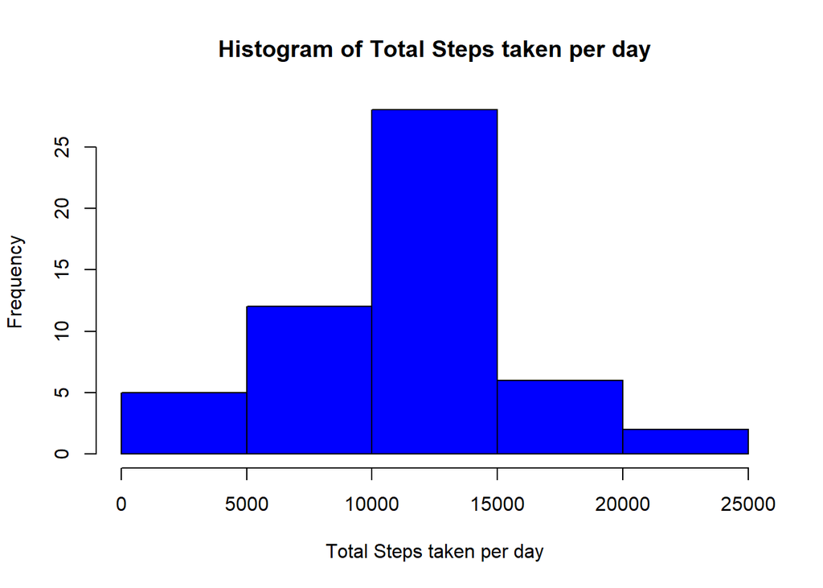

```r
hist(totalSteps$steps,col="blue",main="Histogram of Total Steps taken per day",xlab="Total Steps taken per day",cex.axis=1,cex.lab = 1)
```

```r
### Calculate and report the mean and median total number of steps taken per day

mean.steps <- mean(totalSteps$steps)
mean.steps
```

```
## [1] 10766.19
```

```r
median.steps <- median(totalSteps$steps)
median.steps
```

```
## [1] 10765
```

What is the average daily activity pattern? Make a time series plot (i.e. type = “l”) of the 5-minute interval (x-axis) and the average number of steps taken, averaged across all days (y-axis)

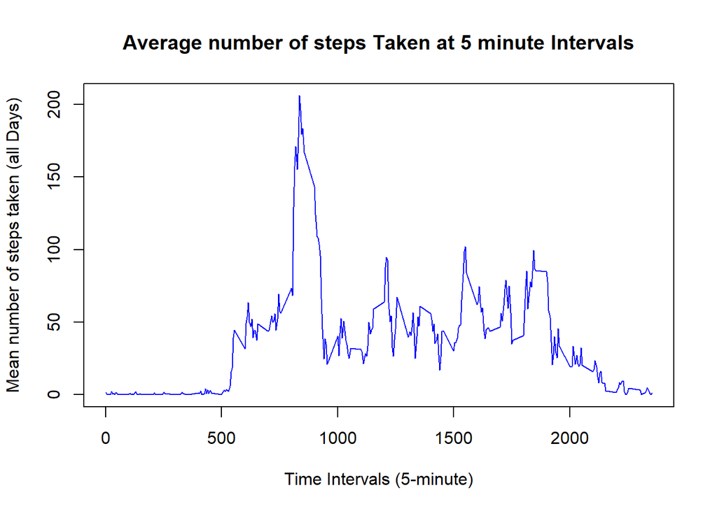

```r
steps_interval <- aggregate(steps ~ interval, data = activity, mean, na.rm = TRUE)
plot(steps ~ interval, data = steps_interval, type = "l", xlab = "Time Intervals (5-minute)", ylab = "Mean number of steps taken (all Days)", main = "Average number of steps Taken at 5 minute Intervals",  col = "blue")
```

```r
## Which 5-minute interval, on average across all the days in the dataset, contains the maximum number of steps?

maxStepInterval <- steps_interval[which.max(steps_interval$steps),"interval"]
maxStepInterval
```

```
## [1] 835
```

Imputing missing values Calculate and report the total number of missing values in the dataset (i.e. the total number of rows with NAs)

```r
missing_rows <- sum(!complete.cases(activity))
missing_rows ## total missing rows
```

```
## [1] 2304
```

Devise a strategy for filling in all of the missing values in the dataset. The strategy does not need to be sophisticated. For example, you could use the mean/median for that day, or the mean for that 5-minute interval, etc.

## This function returns the mean steps for a given interval

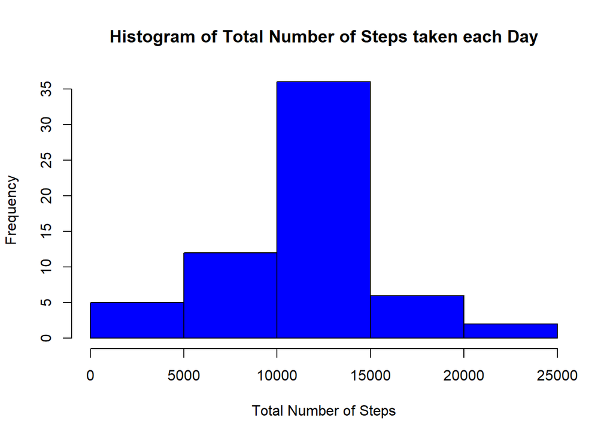

```r
getMeanStepsPerInterval <- function(interval){
    steps_interval[steps_interval$interval==interval,"steps"]
    }
## Create a new dataset that is equal to the original dataset but with the missing data filled in.

complete.activity <- activity

## Filling the missing values with the mean for that 5-minute interval
flag = 0
for (i in 1:nrow(complete.activity)) {
    if (is.na(complete.activity[i,"steps"])) {
        complete.activity[i,"steps"] <- getMeanStepsPerInterval(complete.activity[i,"interval"])
        flag = flag + 1
        }
    }

##Total of 2304 missing values were filled.
##Make a histogram of the total number of steps taken each day.

total.steps.per.days <- aggregate(steps ~ date, data = complete.activity, sum)
hist(total.steps.per.days$steps, col = "blue", xlab = "Total Number of Steps",
     ylab = "Frequency", main = "Histogram of Total Number of Steps taken each Day")
```

Calculate and report the mean and median total number of steps taken per day.

```r
showMean <- mean(total.steps.per.days$steps)
showMedian <- median(total.steps.per.days$steps)
showMean
```

```
## [1] 10766.19
```

```r
showMedian
```

```
## [1] 10766.19
```

Do these values differ from the estimates from the first part of the assignment? Imputing missing values keep the mean unchanged but the median was changed.

What is the impact of imputing missing data on the estimates of the total daily number of steps?

The mean value is the same as the value before imputing missing data since the mean value has been used for that particular 5-min interval. The median value is different, since the median index is now being changed after imputing missing values.

Are there differences in activity patterns between weekdays and weekends? Create a new factor variable in the dataset with two levels - “weekday”" and “weekend”" indicating whether a given date is a weekday or weekend day.

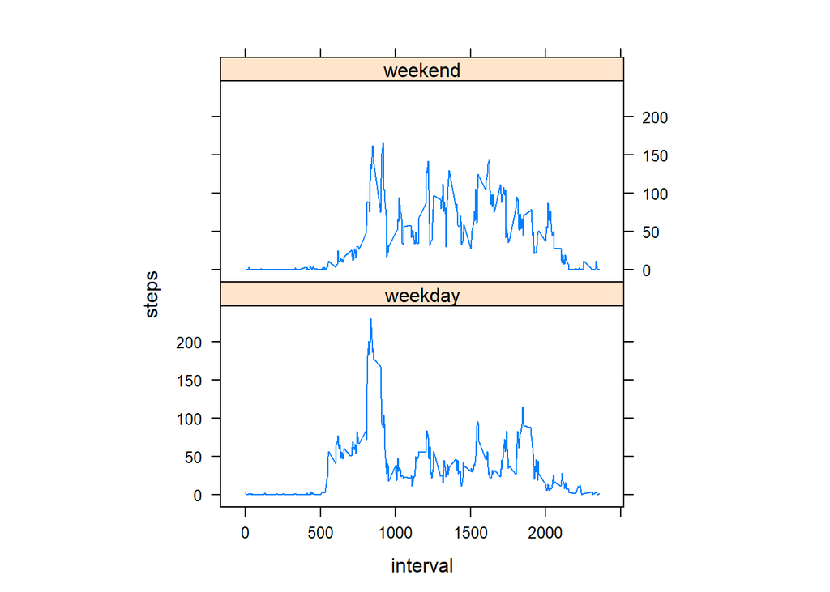

```r
complete.activity$day <- ifelse(as.POSIXlt(as.Date(complete.activity$date))$wday%%6 ==
                                    0, "weekend", "weekday")
complete.activity$day <- factor(complete.activity$day, levels = c("weekday", "weekend"))

## Make a panel plot containing a time series plot (i.e. type = "l") of the 5-minute interval (x-axis) and the average number of steps taken, averaged across all weekday days or weekend days (y-axis).

steps.interval= aggregate(steps ~ interval + day, complete.activity, mean)
library(lattice)
xyplot(steps ~ interval | factor(day), data = steps.interval, aspect = 1/2,
       type = "l")
```